```r
library(moments)
library(corrplot)
```

## Airline Flight Delays

Hunter Dunn and Breanna Ranglall

```r
Flights <- read.csv("C:/Users/xst-rang5397/OneDrive - University of St. Thomas (1)/flights.csv")
Flights <- Flights[,c("DAY_OF_WEEK", "Top50", "SCHEDULED_TIME", "ELAPSED_TIME", "DISTANCE", "AIR_SYSTEM_DELAY", "SECURITY_DELAY", "LATE_AIRCRAFT_DELAY", "WEATHER_DELAY", "ARRIVAL_DELAY")]
```

## Removal/Adjustments to Data

Something to notice is the addition of the “Top50” variable. Since “AIRLINE” used character variables, we could not use it for data analysis. Therefore, we opted to categorize the airline by the ones who were in the Top 50 airlines in the world, and those who weren’t.

This data file had over one million cases. This large number of cases is very difficult to code with, for example, graphs do not want to load and we cannot knit to HTML. All of the data is from 2015, so we opted to use data from “January” only.

```r
Flights <- Flights[1:469969,]
#Flights <- Flights[1:13951,]
#Flights <- Flights[469970:899160,]
```

Even with this change, we still have 469,969 cases. Therefore, we opted to remove data using the “Complete Observations” method. We believed that “Complete Pairwise Observations” was not necessary because even after removing all the cases with missing data, we still have 95,951 cases to use for analysis which is more than enough.

```r
#Remove missing data
Flights <- Flights |>
  na.omit(Flights)
```

## One-Dimensional Data Visualization/Summary

Means/Central Tendency:

```r
print('Means/Central Tendency:')
```

```
## [1] "Means/Central Tendency:"
```

```r
for(x in 1:10){
  print(paste(colnames(Flights[x]), ": ", mean(Flights[,x])))
}
```

```
## [1] "DAY_OF_WEEK :  4.11221352565372"
## [1] "Top50 :  0.272180592177257"
## [1] "SCHEDULED_TIME :  139.487926128962"
## [1] "ELAPSED_TIME :  145.226532292524"
## [1] "DISTANCE :  801.517336974081"
## [1] "AIR_SYSTEM_DELAY :  13.3198716011297"
## [1] "SECURITY_DELAY :  0.0698273076882992"
## [1] "LATE_AIRCRAFT_DELAY :  22.7602109410011"
## [1] "WEATHER_DELAY :  2.74188908922262"
## [1] "ARRIVAL_DELAY :  56.6941668143115"
```

Standard Deviation/Dispersion:

```r
print('Standard Deviation/Dispersion:')
```

```
## [1] "Standard Deviation/Dispersion:"
```

```r
for(x in 1:10){
  print(paste(colnames(Flights[x]), ": ", sd(Flights[,x])))

}
```

```
## [1] "DAY_OF_WEEK :  2.039737583816"
## [1] "Top50 :  0.445084690838437"
## [1] "SCHEDULED_TIME :  73.5625047343215"
## [1] "ELAPSED_TIME :  75.4832223312437"
## [1] "DISTANCE :  588.758250869364"
## [1] "AIR_SYSTEM_DELAY :  24.7231112592413"
## [1] "SECURITY_DELAY :  2.0681161220551"
## [1] "LATE_AIRCRAFT_DELAY :  40.9397507132883"
## [1] "WEATHER_DELAY :  18.5104428436967"
## [1] "ARRIVAL_DELAY :  60.412771265665"
```

Kurtosis:

```r
print('Kurtosis:')
```

```
## [1] "Kurtosis:"
```

```r
for(x in 1:10){
  print(paste(colnames(Flights[x]), ": ", kurtosis(Flights[,x])))

}
```

```
## [1] "DAY_OF_WEEK :  1.76371273738919"
## [1] "Top50 :  2.0479984536335"
## [1] "SCHEDULED_TIME :  5.86489578176228"
## [1] "ELAPSED_TIME :  5.68283472192424"
## [1] "DISTANCE :  6.04269061805196"
## [1] "AIR_SYSTEM_DELAY :  82.0483448801286"
## [1] "SECURITY_DELAY :  5852.51570656071"
## [1] "LATE_AIRCRAFT_DELAY :  37.323611907239"
## [1] "WEATHER_DELAY :  390.967247842866"
## [1] "ARRIVAL_DELAY :  74.5752698286732"
```

Skewness:

```r
print('skewness:')
```

```
## [1] "skewness:"
```

```r
for(x in 1:10){
  print(paste(colnames(Flights[x]), ": ", skewness(Flights[,x])))
}
```

```
## [1] "DAY_OF_WEEK :  -0.134625062210737"
## [1] "Top50 :  1.02371795609606"
## [1] "SCHEDULED_TIME :  1.45269137927465"
## [1] "ELAPSED_TIME :  1.39166560814826"
## [1] "DISTANCE :  1.50857235903852"
## [1] "AIR_SYSTEM_DELAY :  5.96551909038998"
## [1] "SECURITY_DELAY :  63.3246891920749"
## [1] "LATE_AIRCRAFT_DELAY :  4.08761432894843"
## [1] "WEATHER_DELAY :  15.3870350290018"
## [1] "ARRIVAL_DELAY :  5.5296743402142"
```

Dotplots:

```r
print('dotplot:')
```

```
## [1] "dotplot:"
```

```
## [1] "DAY_OF_WEEK"
```

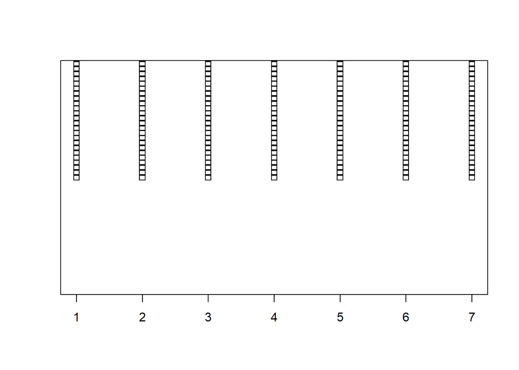

```
## [1] "Top50"
```

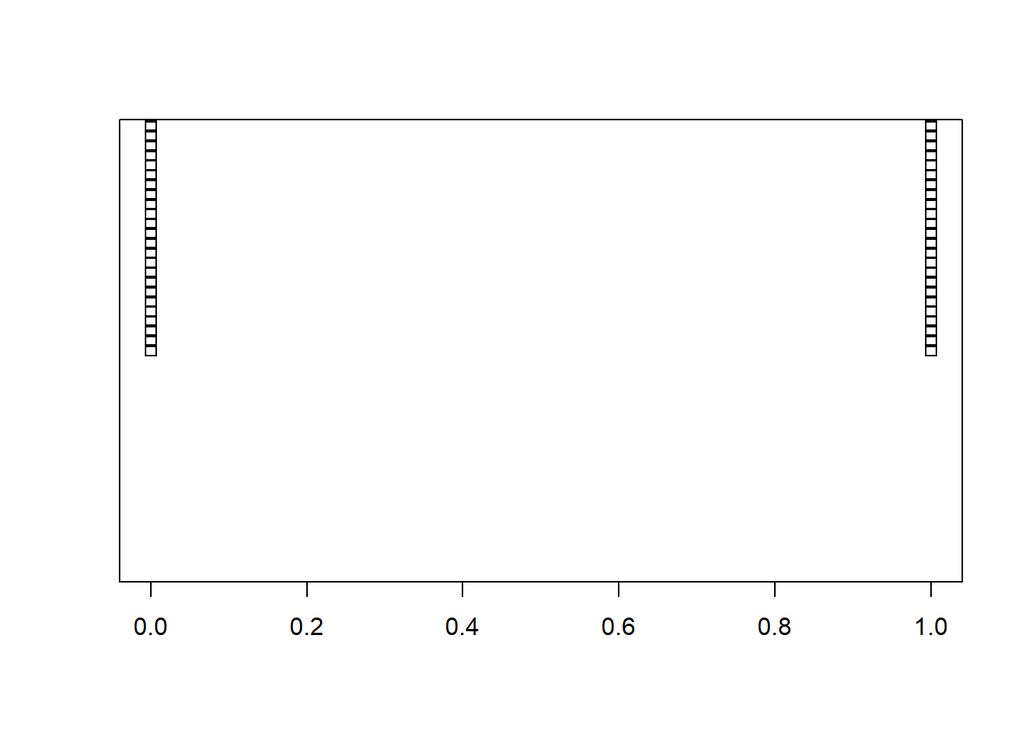

```
## [1] "SCHEDULED_TIME"
```

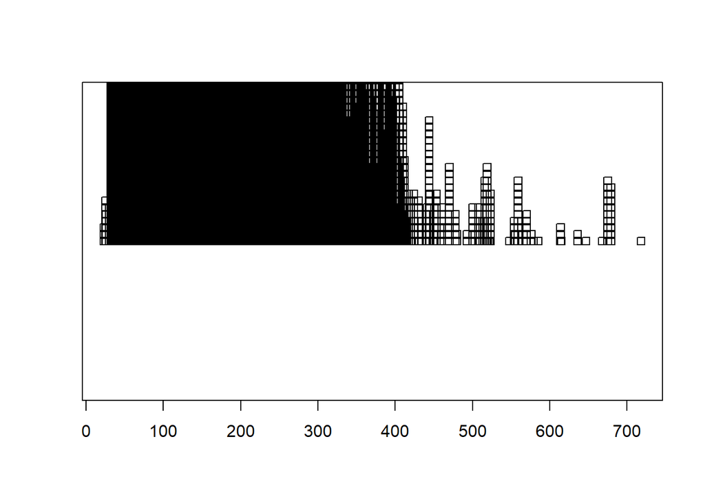

```
## [1] "ELAPSED_TIME"
```

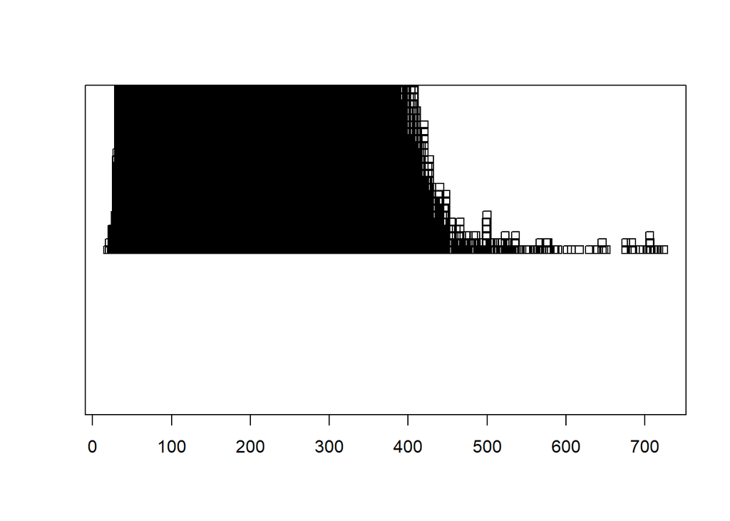

```
## [1] "DISTANCE"
```

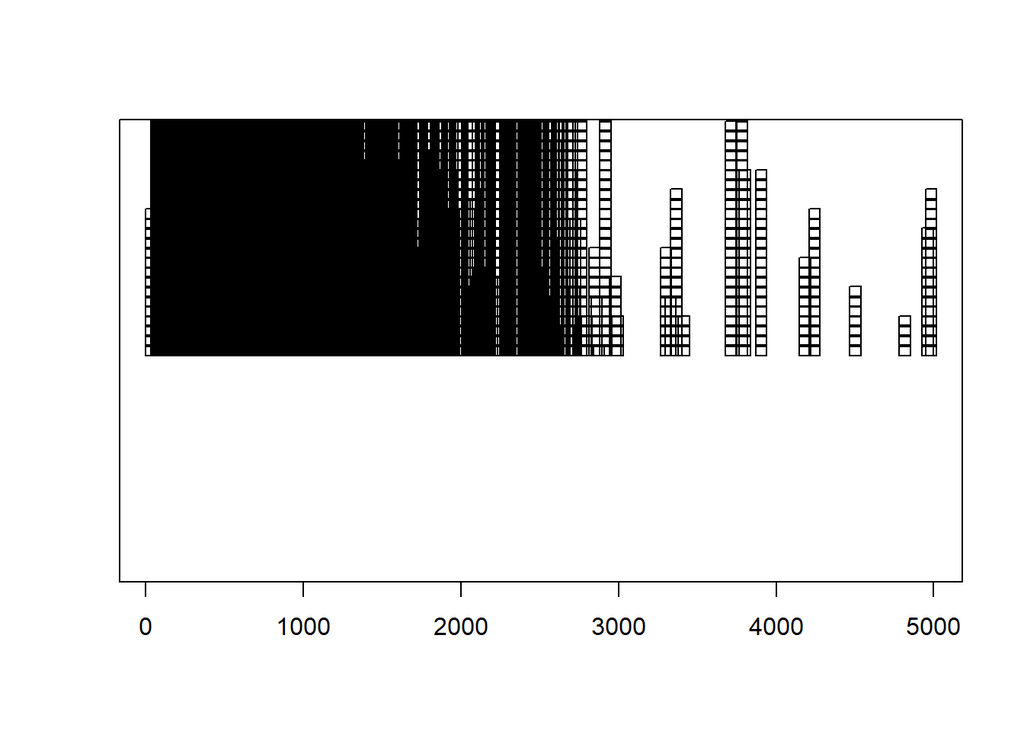

```
## [1] "AIR_SYSTEM_DELAY"
```

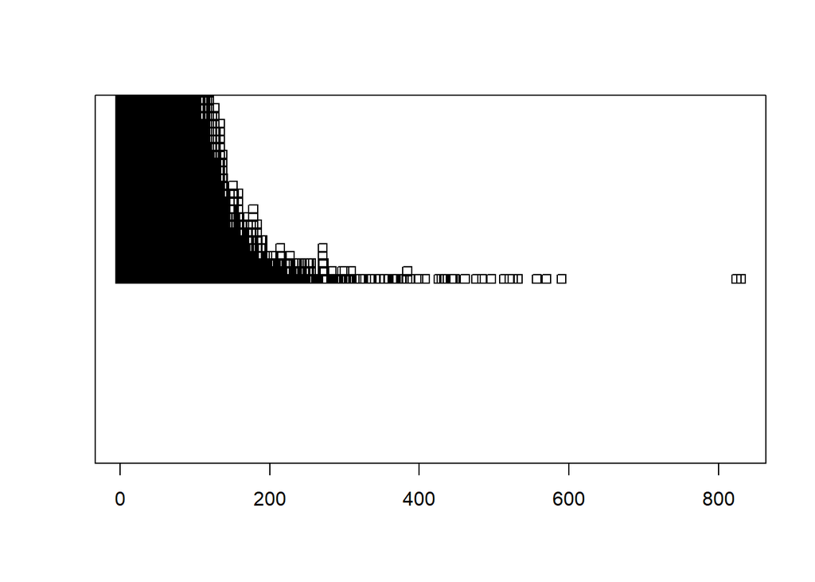

```
## [1] "SECURITY_DELAY"
```

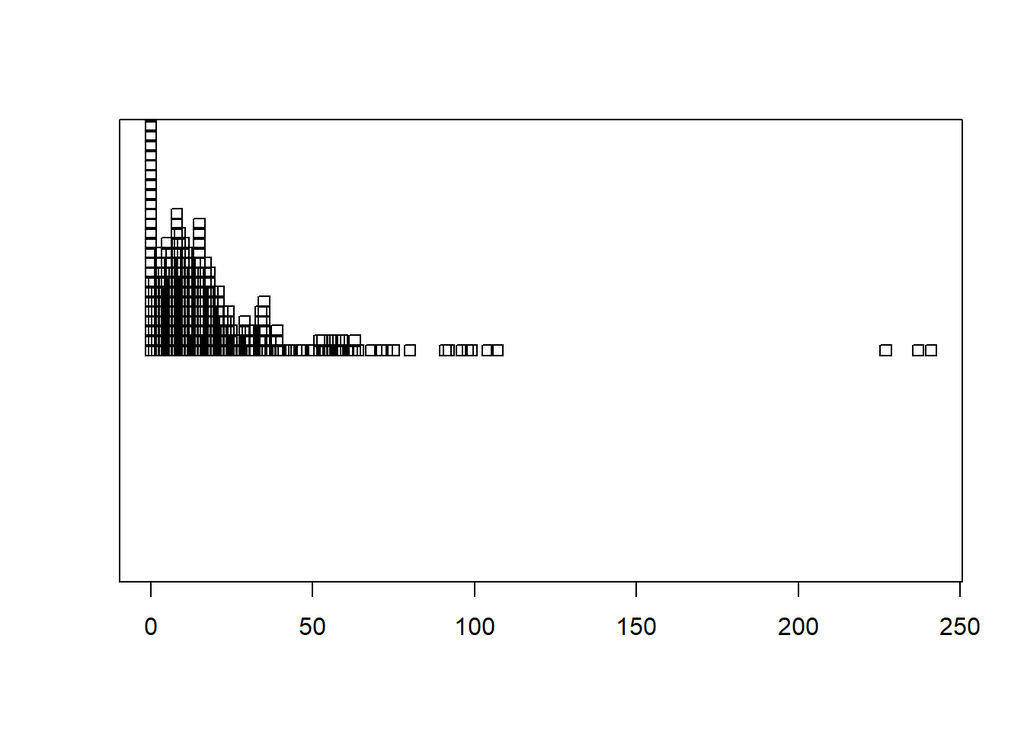

```
## [1] "LATE_AIRCRAFT_DELAY"
```

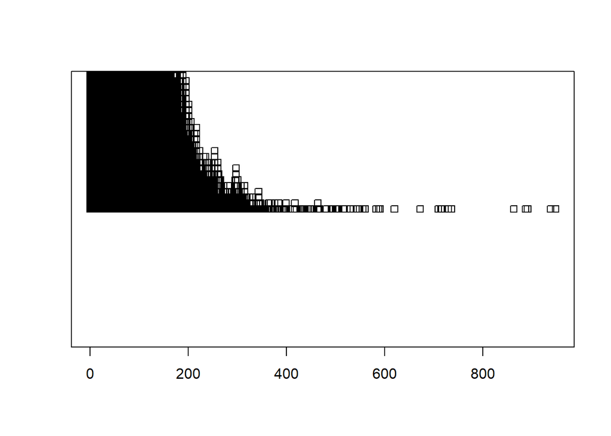

```
## [1] "WEATHER_DELAY"
```

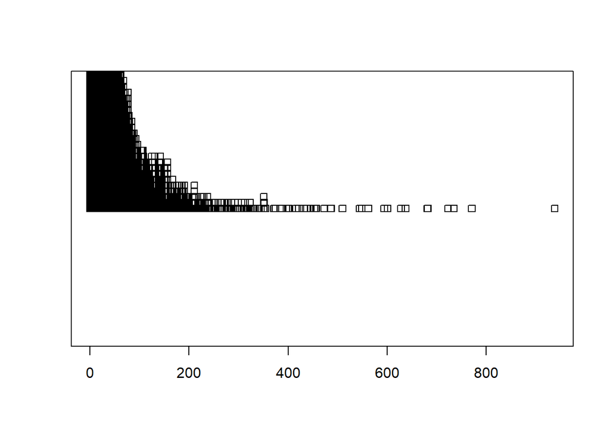

```
## [1] "ARRIVAL_DELAY"
```

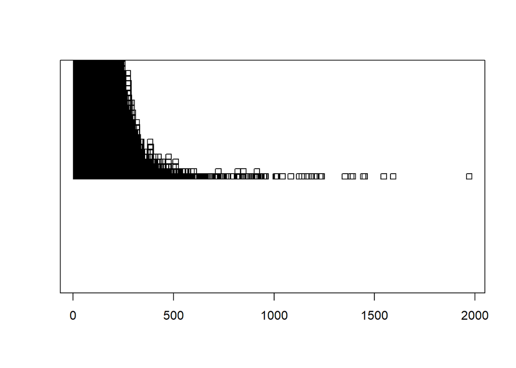

```r
for(x in 1:10){
  print(colnames(Flights[x]))
  stripchart(Flights[,x], method = "stack")
}
```

All numeric variables except for “DAYS_OF_THE_WEEK” are right-skewed, however, “SECURITY_DELAY” is the most right-skewed. Regarding Kurtosis, all but “DAY_OF_WEEK” and “Top50” are leptokurtic.

## Two-Dimensional Data Visualization/Summary

Covariance Matrix:

```r
SIGMA <- cov(Flights)
SIGMA
```

```
##                     DAY_OF_WEEK        Top50 SCHEDULED_TIME  ELAPSED_TIME
## DAY_OF_WEEK          4.16052941  0.015283289       5.166769     4.4317762
## Top50                0.01528329  0.198100382       9.962932     9.5341624
## SCHEDULED_TIME       5.16676914  9.962931956    5411.442103  5374.8931364
## ELAPSED_TIME         4.43177620  9.534162404    5374.893136  5697.7168535
## DISTANCE            53.76450060 75.007433326   42324.568002 41974.0529876
## AIR_SYSTEM_DELAY    -1.13759310 -0.143937121      45.751304   301.5170638
## SECURITY_DELAY       0.04460833 -0.005978217       1.209817     0.7837023
## LATE_AIRCRAFT_DELAY  1.66589691 -0.842820937    -195.657934  -325.0649812
## WEATHER_DELAY       -0.75892569  0.288492179      -5.479344     8.2270172
## ARRIVAL_DELAY        0.99361028  0.232466279     -36.683375    -8.6283836
##                         DISTANCE AIR_SYSTEM_DELAY SECURITY_DELAY
## DAY_OF_WEEK             53.76450       -1.1375931    0.044608331
## Top50                   75.00743       -0.1439371   -0.005978217
## SCHEDULED_TIME       42324.56800       45.7513035    1.209816518
## ELAPSED_TIME         41974.05299      301.5170638    0.783702279
## DISTANCE            346636.27797      163.0153923   11.486366256
## AIR_SYSTEM_DELAY       163.01539      611.2322303   -0.632862321
## SECURITY_DELAY          11.48637       -0.6328623    4.277104294
## LATE_AIRCRAFT_DELAY  -1559.19594     -137.4874038   -0.964048080
## WEATHER_DELAY         -123.48542        3.1509009   -0.112805179
## ARRIVAL_DELAY         -681.44263      342.5165256    1.569641296
##                     LATE_AIRCRAFT_DELAY WEATHER_DELAY ARRIVAL_DELAY
## DAY_OF_WEEK                   1.6658969    -0.7589257     0.9936103
## Top50                        -0.8428209     0.2884922     0.2324663
## SCHEDULED_TIME             -195.6579343    -5.4793436   -36.6833748
## ELAPSED_TIME               -325.0649812     8.2270172    -8.6283836
## DISTANCE                  -1559.1959365  -123.4854157  -681.4426341
## AIR_SYSTEM_DELAY           -137.4874038     3.1509009   342.5165256
## SECURITY_DELAY               -0.9640481    -0.1128052     1.5696413
## LATE_AIRCRAFT_DELAY        1676.0631885   -16.5822472  1330.5725731
## WEATHER_DELAY               -16.5822472   342.6364943   287.0587049
## ARRIVAL_DELAY              1330.5725731   287.0587049  3649.7029320
```

Correlation Matrix:

```r
R <- cor(Flights)
R
```

```
##                      DAY_OF_WEEK        Top50 SCHEDULED_TIME ELAPSED_TIME
## DAY_OF_WEEK          1.000000000  0.016834486    0.034434062  0.028784129
## Top50                0.016834486  1.000000000    0.304290224  0.283785014
## SCHEDULED_TIME       0.034434062  0.304290224    1.000000000  0.967972221
## ELAPSED_TIME         0.028784129  0.283785014    0.967972221  1.000000000
## DISTANCE             0.044769713  0.286236255    0.977235015  0.944481528
## AIR_SYSTEM_DELAY    -0.022558464 -0.013080581    0.025156131  0.161569113
## SECURITY_DELAY       0.010574668 -0.006494626    0.007952214  0.005020255
## LATE_AIRCRAFT_DELAY  0.019949345 -0.046253805   -0.064967441 -0.105190026
## WEATHER_DELAY       -0.020100560  0.035016649   -0.004023975  0.005888100
## ARRIVAL_DELAY        0.008063304  0.008645469   -0.008254372 -0.001892127
##                         DISTANCE AIR_SYSTEM_DELAY SECURITY_DELAY
## DAY_OF_WEEK          0.044769713     -0.022558464    0.010574668
## Top50                0.286236255     -0.013080581   -0.006494626
## SCHEDULED_TIME       0.977235015      0.025156131    0.007952214
## ELAPSED_TIME         0.944481528      0.161569113    0.005020255
## DISTANCE             1.000000000      0.011199238    0.009433454
## AIR_SYSTEM_DELAY     0.011199238      1.000000000   -0.012377450
## SECURITY_DELAY       0.009433454     -0.012377450    1.000000000
## LATE_AIRCRAFT_DELAY -0.064687221     -0.135835909   -0.011386194
## WEATHER_DELAY       -0.011330833      0.006885172   -0.002946709
## ARRIVAL_DELAY       -0.019158590      0.229324074    0.012563098
##                     LATE_AIRCRAFT_DELAY WEATHER_DELAY ARRIVAL_DELAY
## DAY_OF_WEEK                  0.01994934  -0.020100560   0.008063304
## Top50                       -0.04625381   0.035016649   0.008645469
## SCHEDULED_TIME              -0.06496744  -0.004023975  -0.008254372
## ELAPSED_TIME                -0.10519003   0.005888100  -0.001892127
## DISTANCE                    -0.06468722  -0.011330833  -0.019158590
## AIR_SYSTEM_DELAY            -0.13583591   0.006885172   0.229324074
## SECURITY_DELAY              -0.01138619  -0.002946709   0.012563098
## LATE_AIRCRAFT_DELAY          1.00000000  -0.021881716   0.537978123
## WEATHER_DELAY               -0.02188172   1.000000000   0.256699578
## ARRIVAL_DELAY                0.53797812   0.256699578   1.000000000
```

Scatterplot Matrix:

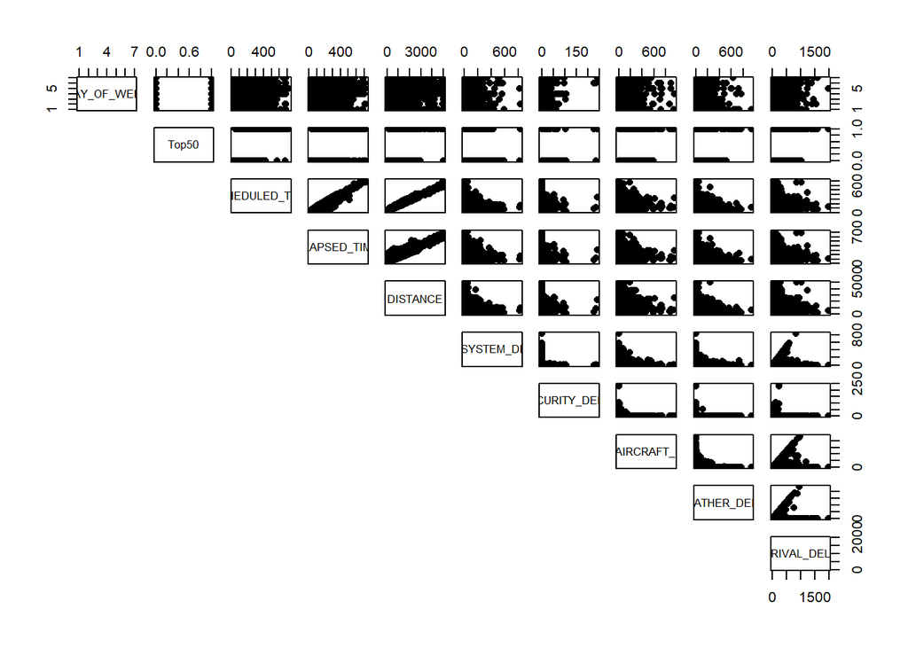

```r
pairs(Flights, pch = 16, lower.panel = NULL)
```

Correlation plot:

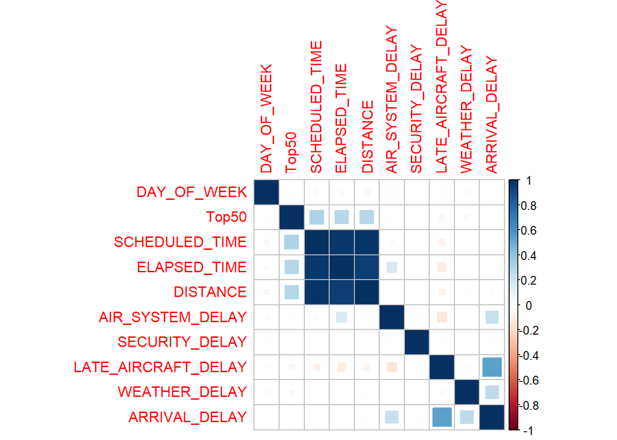

```r
corrplot(R, method = "square")
```

Based on the Correlation Matrix and Plot, there is the most correlation between “ELAPSED_TIME” and “SCHEDULED_TIME”, “DISTANCE” and “SCHEDULED_TIME”, and “DISTANCE” and “ELAPSED_TIME”.

## Two-Dimensional Outliers

Based on the scatterplot matrix. The largest potential outlier seems to be from “AIR_SYSTEM_DELAY” and “SECURITY_DELAY”.

I will calculate a critical value at 0.05 and use Mahalanobis distance to determine if it’s an outlier.

```r
m <- mahalanobis(x = Flights[,c(6,7)],
            center = c(mean(Flights[,6]), mean(Flights[,7])),
            cov = cov(Flights[,c(6,7)]))
critical <- qchisq(p = 1 - 0.05, df = 2)
```

Remove the outliers and create a new to determine if they’re influential.

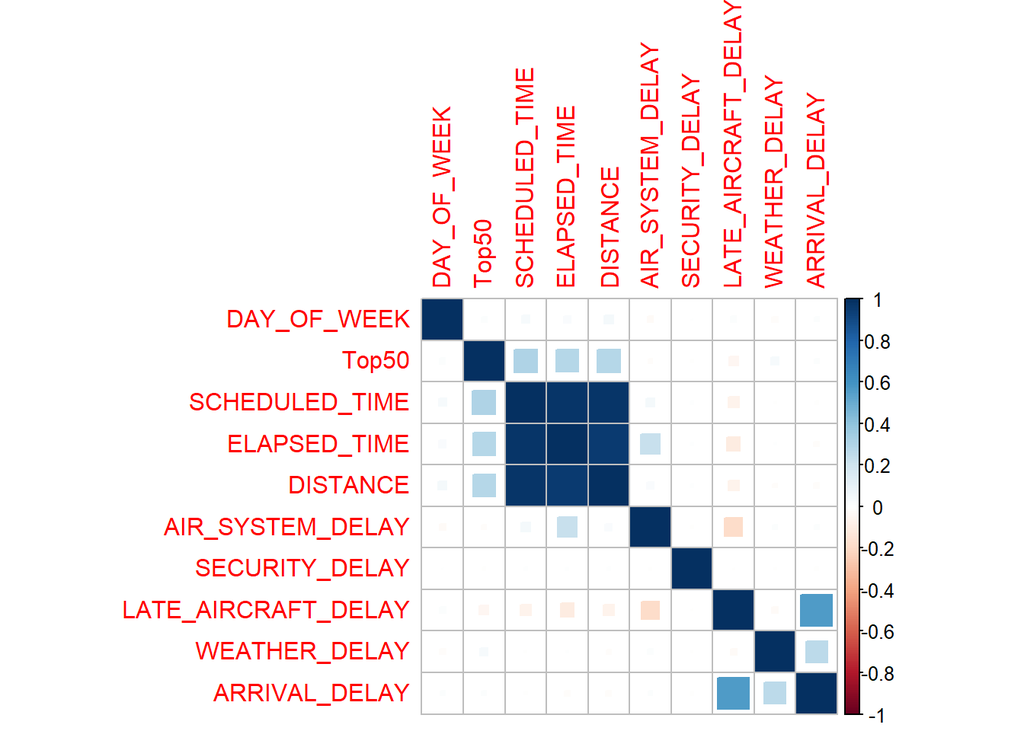

```r
R <- cor(Flights[-which(m > critical),])
corrplot(R, method = "square")
```